# How to Program a Quantum Computer

## Neereja Sundaresan, Maika Takita, Soolu Thomas

### September 29, 2020

### Before we begin...

Make sure that you've joined the **`#vghc2020-qiskit-workshop`** slack channel in [Qiskit Workspace](https://ibm.co/joinqiskitslack)! (See the README.md file for more info)

Check https://github.com/sooluthomas/ghc2020 for the slack channel invite link.

Follow the steps:

1. Join the **Qiskit workspace** - https://ibm.co/joinqiskitslack
2. Search and join the slack channel - **#vghc2020-qiskit-workshop**

# Let's start programming!

### Running the IBM Quantum Experience

This will run Qiskit seamlessly in your browser. All you need to do is sign up for an IBMid or log in with your existing account, such as Google, GitHub, LinkedIn, or Twitter. And then you’re ready to start writing your first quantum circuit. ibm.co/iqx

### Installing Qiskit

Not everyone needs to install Qiskit now that it fully runs in the cloud on the IBM Quantum Experience, but if you’d like to get into the code, use these resources: ibm.co/installqiskit (video) or ibm.co/installqiskitdoc (documentation)

# Quantum Computer: New model of computation

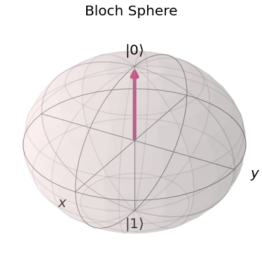

```python
from qiskit.visualization import plot_bloch_vector
%matplotlib inline

plot_bloch_vector([0,0,1], title="Bloch Sphere")
```

## The Pauli Gates

### X, Y, and Z-gates

#### Rotation by $\pi$ around the x, y and z-axis of the Bloch sphere

$$ X = \begin{bmatrix} 0 & 1 \\ 1 & 0 \end{bmatrix} \quad\quad\quad\quad Y = \begin{bmatrix} 0 & -i \\ i & 0 \end{bmatrix} \quad\quad\quad\quad Z = \begin{bmatrix} 1 & 0 \\ 0 & -1 \end{bmatrix} $$

### Quantum Circuits - `QuantumCircuit(qr, cr)`

**Quantum Registers (qr)**: The register to store Quantum information

**Classical Registers (cr)**: The register to store Classical information/results

For more information, check out the [Getting started documentation](https://qiskit.org/documentation/getting_started.html)

### The import statements that we are using are

```python
from qiskit import (QuantumCircuit,
                    QuantumRegister,
                    ClassicalRegister,
                    execute,
                    Aer,
                    IBMQ)
from qiskit.providers import ibmq
from qiskit.visualization import plot_histogram, plot_bloch_multivector
```

```python
#X-gate on |0>
qc = QuantumCircuit(1)
qc.x(0)
qc.draw('mpl')
```

[output not shown]

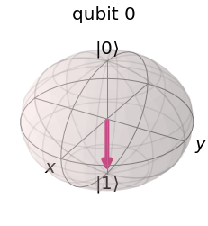

```python
backend = Aer.get_backend('statevector_simulator')
out = execute(qc,backend).result().get_statevector()
plot_bloch_multivector(out)
```

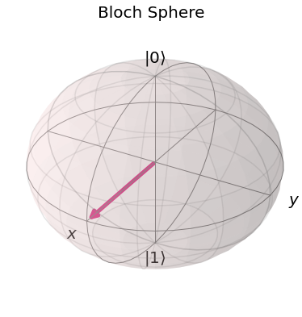

```python
# Around the eqator
plot_bloch_vector([1,0,0], title="Bloch Sphere")
```

## Superposition

In addition to $|0\rangle$ and $|1\rangle$, a single qubit can be a superposition of both.

$$\frac{|0\rangle \pm |1\rangle}{\sqrt{2}}$$

We can create a superposition state using the Hadamard gate

- **Hadamard gate**: The gate that is used to create superposition

  ```
      ┌───┐
     ─┤ H ├─
      └───┘
  ```

- **Measure gate**: To measure the output to a classical register

  ```
         ┌─┐
     q  ─┤M├─
         └╥┘
     c   ═╩═
  ```

```python
qc = QuantumCircuit(1)
qc.h(0)
qc.draw('mpl')
```

[output not shown]

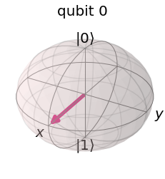

```python
backend = Aer.get_backend('statevector_simulator')
out = execute(qc,backend).result().get_statevector()
plot_bloch_multivector(out)
```

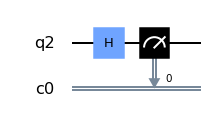

```python
# Add classical register
qr = QuantumRegister(1)
cr = ClassicalRegister(1)
# Building a circuit to create superposition
qc = QuantumCircuit(qr, cr)  # Optionally, we can simply use QuantumCircuit(1, 1)
# Adding gates to the circuit
qc.h(qr)
qc.measure(qr, cr)
# Draw the circuit
qc.draw(output='mpl')
```

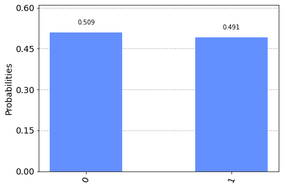

```python
backend = Aer.get_backend('qasm_simulator')
# Execute the circuit
result = execute(qc, backend, shots=1000).result()
# Display the result
plot_histogram(result.get_counts(qc))
```

Try it out:

Which state do you get if you run `shots = 1`

Put your result in a poll in slack channel **`#vghc2020-qiskit-workshop`** in [Qiskit Workspace](https://ibm.co/joinqiskitslack). (See the README.md file for more info)

To know more about other types of visualizations, checkout the [Qiskit Visualizations tutorials](https://qiskit.org/documentation/tutorials/circuits/2_plotting_data_in_qiskit.html)

# Entanglement

We can also create states involving multiple qubits that have non-classical correlations. Such a state could look like $ \frac{|00\rangle \pm |11\rangle}{\sqrt{2}}$

If we measure one qubit at a time the outcome looks random, but if we measure both qubits we only find 00 or 11

We can create an entangled state using the CNOT gate

- **CNOT gate**: The gate that is used to create entanglement

  ```
   q0 ───■───
       ┌─┴─┐
   q1 ─┤ X ├─
       └───┘
  ```

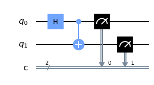

```python
bell_circuit = QuantumCircuit(2, 2)

bell_circuit.h(0)
bell_circuit.cx(0, 1)

bell_circuit.measure([0, 1], [0, 1])

bell_circuit.draw(output='mpl')
```

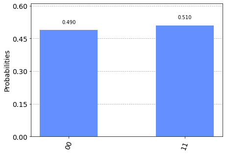

```python
# Execute the circuit
simulator_counts = execute(bell_circuit, backend, shots=1000).result().get_counts()
# Display the result
plot_histogram(simulator_counts)
```

For more information about other gates, check the [tutorials](https://qiskit.org/documentation/tutorials/circuits/3_summary_of_quantum_operations.html#Single-Qubit-Quantum-states)

### Time to run the `bell_circuit` on real Quantum computer!!

For more information on how to use IBM Systems, go to this [documentation](https://qiskit.org/documentation/install.html#access-ibm-quantum-systems)

### Quantum computers available at IBM

#### https://quantum-computing.ibm.com/docs/manage/backends/

```python
provider = IBMQ.load_account()
for backend in provider.backends(simulator=False, operational=True):
    print(backend)
```

[output not shown]

[output cut: 85 more lines]

[output not shown]

```python
from qiskit.tools.jupyter import *
# import qiskit.providers.ibmq.jupyter - for IQX

backend = provider.get_backend('ibmq_santiago')
backend
```

[output not shown]

### How to pick a backend to run on?

- Circuit requirements
- Backend properties
- Backend availability

```python
from qiskit.providers.ibmq import least_busy

small_devices = provider.backends(filters=lambda x: x.configuration().n_qubits == 5
                                   and not x.configuration().simulator)

least_busy(small_devices)
```

[output not shown]

`backend = provider.get_backend('ibmq_valencia')`

## or use least busy real backend

`backend = least_busy(small_devices)`

## or use fake backend for speedy result

`from qiskit.test.mock import FakeVigo`  
`backend = FakeVigo()`

```python
# put backend of your choice

from qiskit.test.mock import FakeVigo
backend = FakeVigo()
backend
```

```
<FakeVigo('fake_vigo') from None()>
```

```python
print('Running circuit on ', backend)

bell_job = execute(bell_circuit, backend)
print(bell_job.job_id())
```

```
Running circuit on  fake_vigo
08757693-c319-415a-9cb4-78c2298ba31b
```

```python
bell_job.status()
```

```
<JobStatus.DONE: 'job has successfully run'>
```

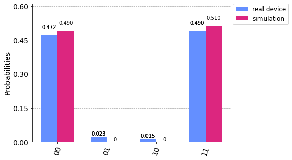

```python
# run this cell when bell_job.status() outputs: <JobStatus.DONE: 'job has successfully run'>

device_counts = bell_job.result().get_counts()

plot_histogram([device_counts, simulator_counts], legend = ['real device', 'simulation'])
```

```python
from qiskit.quantum_info.analysis import hellinger_fidelity

target = {'00': 0.5, '11': 0.5}

hellinger_fidelity(device_counts, target)
```

```
0.8611711694291888
```

# Optimizing quantum circuits for running on quantum hardware

## Circuit Transpilation: [Transpiler documentation](https://qiskit.org/documentation/apidoc/transpiler.html)

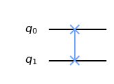

```python
# Translating to Basis Gates
swap_circ = QuantumCircuit(2)
swap_circ.swap(0, 1)
swap_circ.draw(output='mpl')
```

[output not shown]

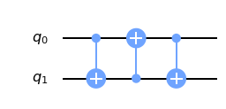

```python
swap_circ_decompose = swap_circ.decompose()
print('Operations in circuit:', swap_circ.depth(), ', Basis gates: ', swap_circ_decompose.depth())
swap_circ.decompose().draw(output='mpl')
```

## Let's try another example!

### 5 qubit entangled state

$$\frac{|00000\rangle \pm |11111\rangle}{\sqrt{2}}$$

See https://quantum-computing.ibm.com/docs/iqx/guide/entanglement#ghz-states for more information

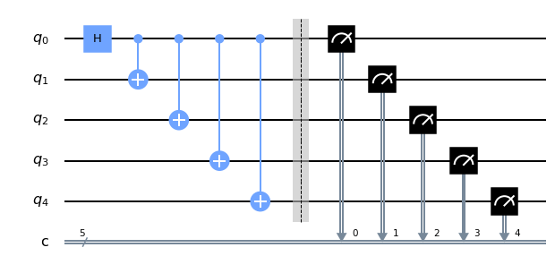

```python
num_bits = 5
entangling_qubits = QuantumCircuit(num_bits, num_bits)

entangling_qubits.h(0)
entangling_qubits.cx(0,1)
entangling_qubits.cx(0,2)
entangling_qubits.cx(0,3)
entangling_qubits.cx(0,4)

entangling_qubits.barrier(range(num_bits))

entangling_qubits.measure(range(num_bits), range(num_bits))

entangling_qubits.draw('mpl')
```

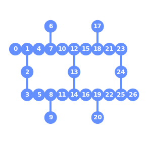

```python
from qiskit.visualization import plot_gate_map, plot_circuit_layout
from qiskit.test.mock import FakeParis

backend = FakeParis()
plot_gate_map(backend, plot_directed=True)
```

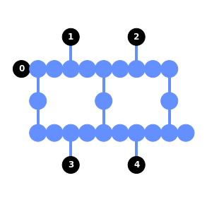

```python
from qiskit import transpile

entangling_qubits_poorly = transpile(entangling_qubits, backend=backend, initial_layout=[0,6,17,9,20])
plot_circuit_layout(entangling_qubits_poorly, backend)
```

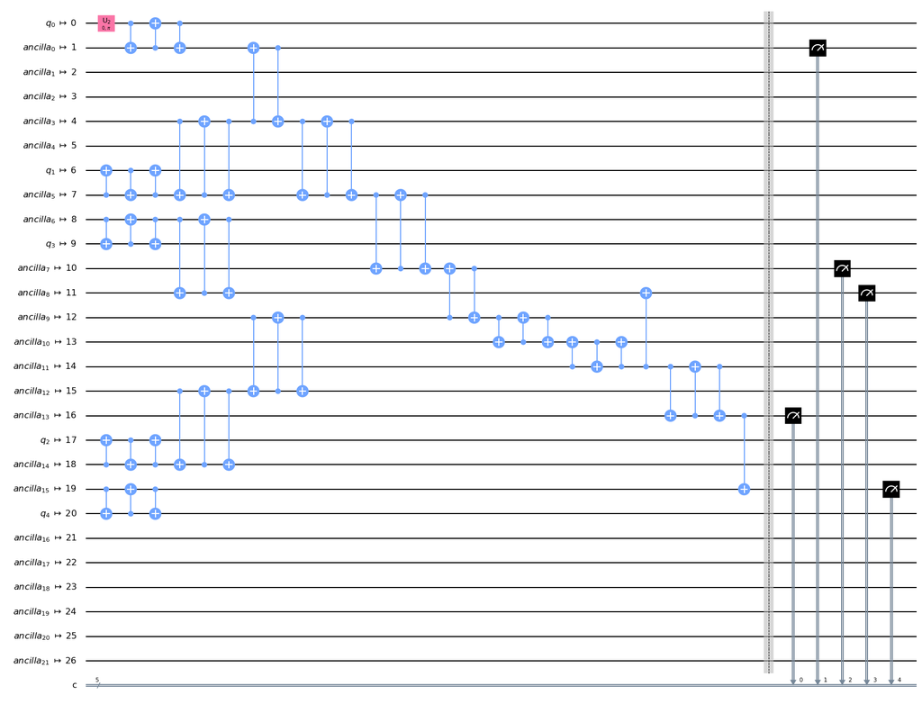

```python
entangling_qubits_poorly.draw(output='mpl',fold=-1)
```

```python
entangling_qubits_poorly.depth()
```

```
28
```

```python
entangling_qubits_poorly.count_ops()
```

```
OrderedDict([('cx', 48), ('measure', 5), ('u2', 1), ('barrier', 1)])
```

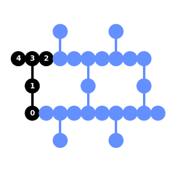

```python
entangling_qubits_opt = transpile(entangling_qubits, backend=backend, optimization_level=3)

plot_circuit_layout(entangling_qubits_opt, backend)
```

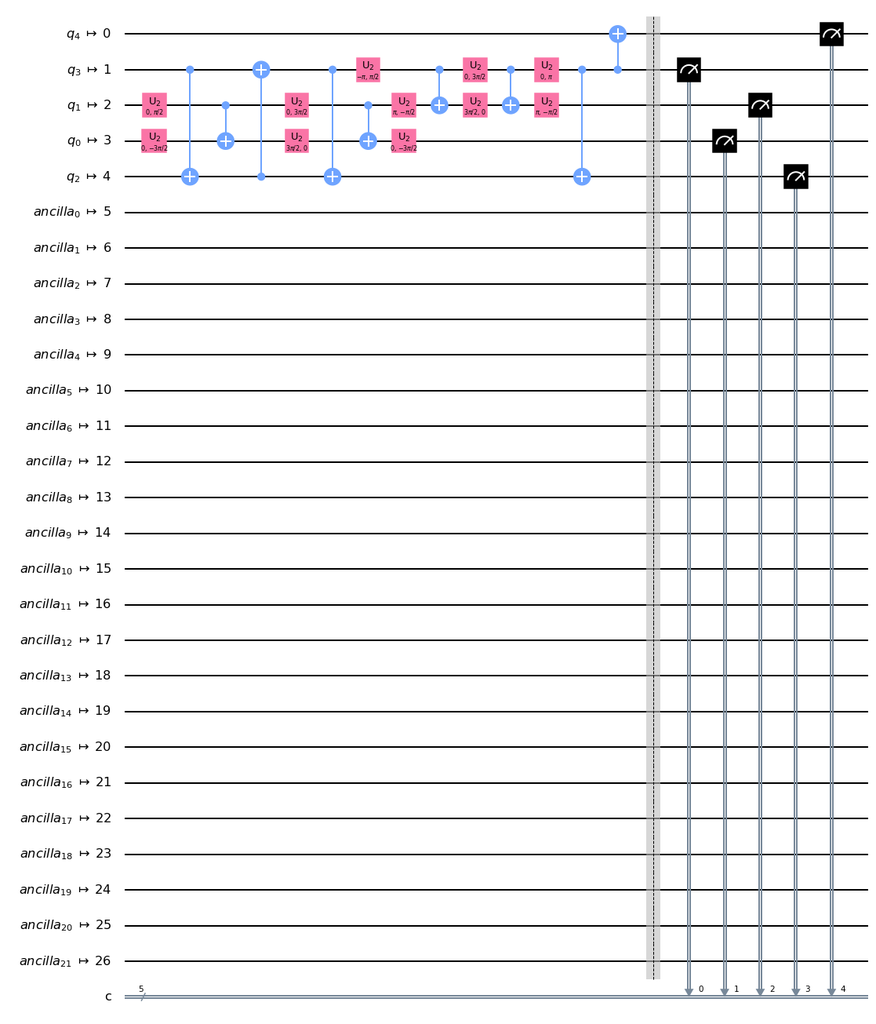

```python
entangling_qubits_opt.draw(output='mpl',fold=-1)
```

```python
entangling_qubits_opt.depth()
```

```
12
```

```python
entangling_qubits_opt.count_ops()
```

```
OrderedDict([('u2', 11), ('cx', 9), ('measure', 5), ('barrier', 1)])
```

```python
# put your choice of backend
backend = FakeVigo()
```

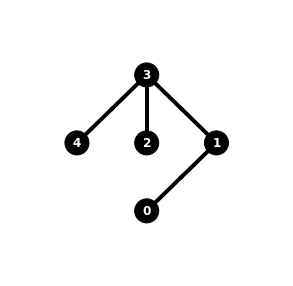

```python
entangling_qubits_backend = transpile(entangling_qubits, backend=backend, optimization_level=3)
plot_circuit_layout(entangling_qubits_backend, backend)
```

```python
entangling_qubits_job = execute(entangling_qubits_backend, backend)
print(entangling_qubits_job.job_id())
```

```
4a668271-1c4a-4a6a-94ac-67479dd22186
```

```python
entangling_qubits_job.status()
```

```
<JobStatus.DONE: 'job has successfully run'>
```

```
0.741709117832386
```

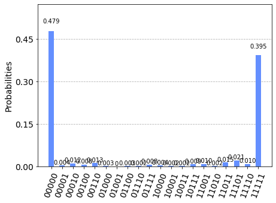

```python
# run this cell when entangling_qubits_job.status() outputs: <JobStatus.DONE: 'job has successfully run'>
counts = entangling_qubits_job.result().get_counts()
target = {'00000': 0.5, '11111': 0.5}
print(hellinger_fidelity(counts, target))
plot_histogram(counts)
```

## Choosing the best qubits for you!

```python
backend
```

```
<FakeVigo('fake_vigo') from None()>
```

```python
edges = backend.configuration().coupling_map
n_qubits = backend.configuration().n_qubits
edges
```

```
[[0, 1], [1, 0], [1, 2], [1, 3], [2, 1], [3, 1], [3, 4], [4, 3]]
```

```python
jobs = []
bell_pairs = []

for q1,q2 in edges:
    circ = QuantumCircuit(n_qubits,2)
    circ.h(q1)
    circ.cx(q1,q2)
    circ.measure([q1,q2], [0, 1])
    bell_pairs.append('Q%d_Q%d' %(q1,q2))

    job = execute(circ, backend,optimization_level=0, shots=8192)
    jobs.append(job)
```

```python
for job in jobs:
        print('%s %s' % (job.job_id(),job.status()) )
```

```
e765be16-68c6-4175-ba2e-6503ee96ee9b JobStatus.DONE
40cb5bbe-7541-4910-bee1-76ea65f7c367 JobStatus.DONE
95db7a1b-2c83-49b7-8ca2-aa9b0985d2c0 JobStatus.DONE
2160ba27-7a5f-48c7-8c03-8b2bb04d4cb8 JobStatus.DONE
d19198b2-aad2-4261-8512-8a5fbfd03c5e JobStatus.DONE
c079e902-2e97-4345-9fed-572649885969 JobStatus.DONE
28e0e085-bdb4-494f-8a44-5b345e91a4ad JobStatus.DONE
3f86d688-fe74-4fa6-a9b0-e8328b50b9f0 JobStatus.DONE
```

```python
fidelities = []
target = {'00': 0.5, '11': 0.5}

for job in jobs:
    fid = hellinger_fidelity(job.result().get_counts(), target)
    fidelities.append(fid)
```

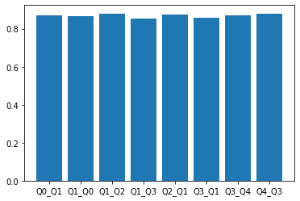

```python
import matplotlib.pyplot as plt

plt.bar(bell_pairs,fidelities)
plt.show()
```

# Next steps!

### Learn Quantum Computing with Qiskit:

https://qiskit.org/textbook/preface.html  
http://qiskit.org/learn

### More tutorials and examples:

https://qiskit.org/documentation/index.html  
https://qisk.it/sub

### Community Events

https://qiskit.org/events

### Slack channel

https://ibm.co/joinqiskitslack

## [CLICK HERE TO PLAY QUANTUM 8 BALL](https://studio.code.org/projects/applab/kZc6NzDM6seJ0a5OtGnLd0nQEbgC3iCBxc1Crg-ValA)

### Other SDKs/ libraries available for Quantum Computing

- https://strawberryfields.readthedocs.io/en/stable/
- https://pyquil-docs.rigetti.com/en/stable/
- https://cirq.readthedocs.io/en/stable/

# THANK YOU!!

```python
import qiskit.tools.jupyter
%qiskit_version_table
%qiskit_copyright
```

Version Information

| Qiskit Software | Version |
| --- | --- |
| Qiskit | 0.20.1 |
| Terra | 0.15.2 |
| Aer | 0.6.1 |
| Ignis | 0.4.0 |
| Aqua | 0.7.5 |
| IBM Q Provider | 0.8.0 |
| System information |  |
| Python | 3.7.8 \| packaged by conda-forge \| (default, Jul 31 2020, 02:25:08) [GCC 7.5.0] |
| OS | Linux |
| CPUs | 8 |
| Memory (Gb) | 31.40900421142578 |
| Tue Sep 29 20:08:53 2020 UTC |  |

This code is a part of Qiskit

© Copyright IBM 2017, 2020.

This code is licensed under the Apache License, Version 2.0. You may  
obtain a copy of this license in the LICENSE.txt file in the root directory  
of this source tree or at http://www.apache.org/licenses/LICENSE-2.0.

Any modifications or derivative works of this code must retain this  
copyright notice, and modified files need to carry a notice indicating  
that they have been altered from the originals.